# Brand Perceptual Map (use PCA for data interpretation)

Mohammad Ali Momen

05/14/2023

**Data Analysis methodology**: CRISP-DM

**Dataset**: 100 Customers answered 9 questions about 10 brands by likerd spectrum

**Case Goal**: Knowing market atmosphere and Brand Positioning (know situation of 10 different Brands)

# 1 Required Libraries

```r
library('pls')
library('ggplot2')
library('corrplot')
```

# 2 Read Data from File

```r
data <- read.csv('CS_10.csv', header = T)
dim(data)  # 1000 records, 10 variables
```

```
## [1] 1000   10
```

> We have 10 brands and 9 features (100 persons evaluate each brand in 9 features by likerd spectrum)

# 3 Business Understanding

- know business process and issues
- know the context of the problem
- know the order of numbers in the business

# 4 Data Understanding

## 4.1 Data Inspection

Data Understanding from Free Perspective

### 4.1.1 Dataset variables definition

```r
colnames(data)
```

```
##  [1] "perform" "leader"  "latest"  "fun"     "serious" "bargain" "value"
##  [8] "trendy"  "rebuy"   "brand"
```

- **perform**: Brand has strong performance
- **leader**: Brand is a leader in the market
- **latest**: Brand has the latest products in market
- **fun**: Brand is fun
- **serious**: Brand is serious
- **bargain**: Brand products are a bargain (are cheap)
- **value**: Brand products are a good value
- **trendy**: Brand is trendy (is trend of market)
- **rebuy**: I would buy from Brand again

## 4.2 Data Exploring

Data Understanding from Statistical Perspective

### 4.2.1 Overview of Dataframe

```r
summary(data)
```

```
##     perform           leader           latest            fun
##  Min.   : 1.000   Min.   : 1.000   Min.   : 1.000   Min.   : 1.000
##  1st Qu.: 1.000   1st Qu.: 2.000   1st Qu.: 4.000   1st Qu.: 4.000
##  Median : 4.000   Median : 4.000   Median : 7.000   Median : 6.000
##  Mean   : 4.488   Mean   : 4.417   Mean   : 6.195   Mean   : 6.068
##  3rd Qu.: 7.000   3rd Qu.: 6.000   3rd Qu.: 9.000   3rd Qu.: 8.000
##  Max.   :10.000   Max.   :10.000   Max.   :10.000   Max.   :10.000
##     serious          bargain           value            trendy
##  Min.   : 1.000   Min.   : 1.000   Min.   : 1.000   Min.   : 1.00
##  1st Qu.: 2.000   1st Qu.: 2.000   1st Qu.: 2.000   1st Qu.: 3.00
##  Median : 4.000   Median : 4.000   Median : 4.000   Median : 5.00
##  Mean   : 4.323   Mean   : 4.259   Mean   : 4.337   Mean   : 5.22
##  3rd Qu.: 6.000   3rd Qu.: 6.000   3rd Qu.: 6.000   3rd Qu.: 7.00
##  Max.   :10.000   Max.   :10.000   Max.   :10.000   Max.   :10.00
##      rebuy           brand
##  Min.   : 1.000   Length:1000
##  1st Qu.: 1.000   Class :character
##  Median : 3.000   Mode  :character
##  Mean   : 3.727
##  3rd Qu.: 5.000
##  Max.   :10.000
```

```r
data$brand <- as.factor(data$brand)
str(data)
```

```
## 'data.frame':    1000 obs. of  10 variables:
##  $ perform: int  2 1 2 1 1 2 1 2 2 3 ...
##  $ leader : int  4 1 3 6 1 8 1 1 1 1 ...
##  $ latest : int  8 4 5 10 5 9 5 7 8 9 ...
##  $ fun    : int  8 7 9 8 8 5 7 5 10 8 ...
##  $ serious: int  2 1 2 3 1 3 1 2 1 1 ...
##  $ bargain: int  9 1 9 4 9 8 5 8 7 3 ...
##  $ value  : int  7 1 5 5 9 7 1 7 7 3 ...
##  $ trendy : int  4 2 1 2 1 1 1 7 5 4 ...
##  $ rebuy  : int  6 2 6 1 1 2 1 1 1 1 ...
##  $ brand  : Factor w/ 10 levels "a","b","c","d",..: 1 1 1 1 1 1 1 1 1 1 ...
```

### 4.2.2 Correlation Analysis

```r
corr_table <- round(cor(data[, 1:9]), 2)  # calculate correlations between continuous variables
corr_table
```

```
##         perform leader latest   fun serious bargain value trendy rebuy
## perform    1.00   0.50  -0.12 -0.26    0.36    0.06  0.10   0.01  0.31
## leader     0.50   1.00   0.03 -0.29    0.57    0.03  0.12   0.07  0.21
## latest    -0.12   0.03   1.00  0.25    0.01   -0.25 -0.34   0.63 -0.40
## fun       -0.26  -0.29   0.25  1.00   -0.28   -0.07 -0.15   0.13 -0.24
## serious    0.36   0.57   0.01 -0.28    1.00    0.00  0.02   0.12  0.18
## bargain    0.06   0.03  -0.25 -0.07    0.00    1.00  0.74  -0.35  0.47
## value      0.10   0.12  -0.34 -0.15    0.02    0.74  1.00  -0.43  0.51
## trendy     0.01   0.07   0.63  0.13    0.12   -0.35 -0.43   1.00 -0.30
## rebuy      0.31   0.21  -0.40 -0.24    0.18    0.47  0.51  -0.30  1.00
```

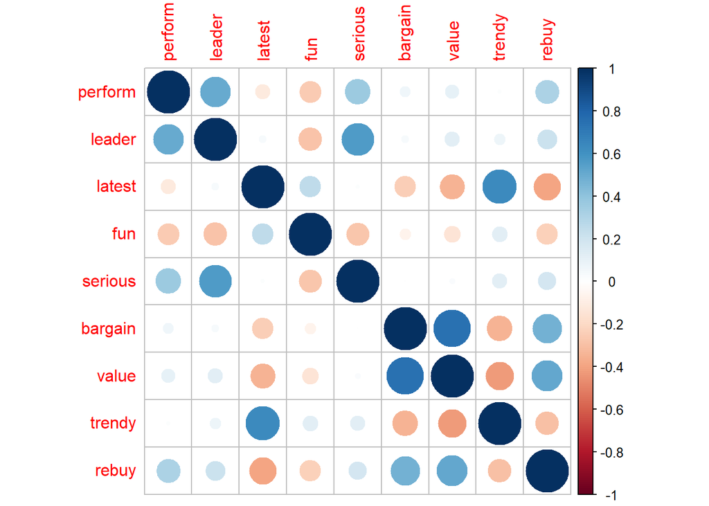

```r
corrplot::corrplot(corr_table)
```

### 4.2.3 Descriptive Analysis on Brands

```r
brand_mean <- aggregate(data[, 1:9], list(data$brand), mean)  # mean score of every brand in each feature
brand_mean  # which brand is better in what?
```

| Group.1 | perform | leader | latest | fun | serious | bargain | value | trendy | rebuy |
| --- | --- | --- | --- | --- | --- | --- | --- | --- | --- |
| a | 1.65 | 3.04 | 7.46 | 7.87 | 1.77 | 4.83 | 4.78 | 3.78 | 2.21 |
| b | 7.47 | 7.21 | 8.43 | 3.40 | 7.61 | 4.37 | 4.70 | 7.25 | 4.33 |
| c | 6.57 | 7.45 | 5.88 | 3.75 | 7.72 | 2.64 | 3.28 | 5.29 | 3.39 |
| d | 2.31 | 2.87 | 7.28 | 6.58 | 2.40 | 1.91 | 2.10 | 7.24 | 2.47 |
| e | 2.68 | 4.92 | 7.60 | 6.88 | 4.44 | 5.73 | 5.34 | 5.60 | 3.82 |
| f | 4.30 | 5.12 | 2.31 | 5.47 | 5.96 | 6.59 | 6.79 | 2.99 | 7.18 |
| g | 7.43 | 3.98 | 2.24 | 4.65 | 2.84 | 6.65 | 7.35 | 1.72 | 7.19 |
| h | 4.44 | 3.64 | 7.74 | 8.03 | 3.93 | 2.29 | 2.46 | 7.59 | 2.19 |
| i | 5.56 | 3.58 | 7.29 | 7.20 | 3.91 | 3.58 | 2.41 | 6.84 | 3.21 |
| j | 2.47 | 2.36 | 5.72 | 6.85 | 2.65 | 4.00 | 4.16 | 3.90 | 1.28 |

```r
rownames(brand_mean) <- brand_mean[, 1]
brand_mean <- brand_mean[,-1]  # remove 'brand' column
brand_mean
```

|  | perform | leader | latest | fun | serious | bargain | value | trendy | rebuy |
| --- | --- | --- | --- | --- | --- | --- | --- | --- | --- |
| a | 1.65 | 3.04 | 7.46 | 7.87 | 1.77 | 4.83 | 4.78 | 3.78 | 2.21 |
| b | 7.47 | 7.21 | 8.43 | 3.40 | 7.61 | 4.37 | 4.70 | 7.25 | 4.33 |
| c | 6.57 | 7.45 | 5.88 | 3.75 | 7.72 | 2.64 | 3.28 | 5.29 | 3.39 |
| d | 2.31 | 2.87 | 7.28 | 6.58 | 2.40 | 1.91 | 2.10 | 7.24 | 2.47 |
| e | 2.68 | 4.92 | 7.60 | 6.88 | 4.44 | 5.73 | 5.34 | 5.60 | 3.82 |
| f | 4.30 | 5.12 | 2.31 | 5.47 | 5.96 | 6.59 | 6.79 | 2.99 | 7.18 |
| g | 7.43 | 3.98 | 2.24 | 4.65 | 2.84 | 6.65 | 7.35 | 1.72 | 7.19 |
| h | 4.44 | 3.64 | 7.74 | 8.03 | 3.93 | 2.29 | 2.46 | 7.59 | 2.19 |
| i | 5.56 | 3.58 | 7.29 | 7.20 | 3.91 | 3.58 | 2.41 | 6.84 | 3.21 |
| j | 2.47 | 2.36 | 5.72 | 6.85 | 2.65 | 4.00 | 4.16 | 3.90 | 1.28 |

Prepare data for heat-map in ggplot2

```r
brand_mean_df <- data.frame(brand = rep(rownames(brand_mean), 9),  # brand names
                var = rep(colnames(brand_mean), each = 10),  # feature names
                mean_value = unlist(brand_mean))  # means
rownames(brand_mean_df) <- NULL  # remove rownames
brand_mean_df
```

| brand | var | mean_value |
| --- | --- | --- |
| a | perform | 1.65 |
| b | perform | 7.47 |
| c | perform | 6.57 |
| d | perform | 2.31 |
| e | perform | 2.68 |
| f | perform | 4.30 |
| g | perform | 7.43 |
| h | perform | 4.44 |
| i | perform | 5.56 |
| j | perform | 2.47 |

[output cut: 80 more lines]

Plot heat-map (relative value of numbers are shown by colors)

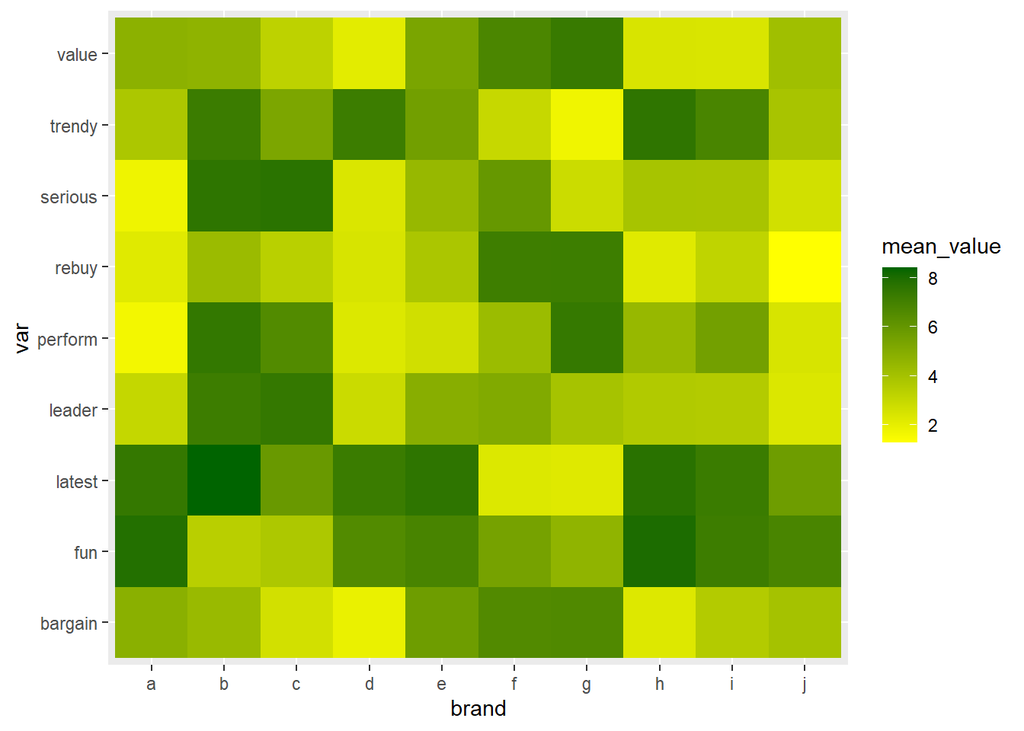

```r
hm_plot <- ggplot(data = brand_mean_df, aes(x = brand, y = var, fill = mean_value)) +
        geom_tile() +
        scale_fill_gradient(low = 'yellow', high = 'dark green')
hm_plot  # try to measure customers emotions about brands (each brand is known as what from customers mindset?), to know our brand's position in the market related to other brands.
```

# 5 Data PreProcessing

## 5.1 Scale data for PCA

```r
data_sc <- data
data_sc[, 1:9] <- scale(data[, 1:9])  # can not scale factor variable ('brand' column)
summary(data_sc)  # bring mean = 0 and distribution around mean
```

```
##     perform            leader            latest             fun
##  Min.   :-1.0888   Min.   :-1.3100   Min.   :-1.6878   Min.   :-1.84677
##  1st Qu.:-1.0888   1st Qu.:-0.9266   1st Qu.:-0.7131   1st Qu.:-0.75358
##  Median :-0.1523   Median :-0.1599   Median : 0.2615   Median :-0.02478
##  Mean   : 0.0000   Mean   : 0.0000   Mean   : 0.0000   Mean   : 0.00000
##  3rd Qu.: 0.7842   3rd Qu.: 0.6069   3rd Qu.: 0.9113   3rd Qu.: 0.70402
##  Max.   : 1.7206   Max.   : 2.1404   Max.   : 1.2362   Max.   : 1.43281
##
##     serious           bargain             value             trendy
##  Min.   :-1.1961   Min.   :-1.22196   Min.   :-1.3912   Min.   :-1.53897
##  1st Qu.:-0.8362   1st Qu.:-0.84701   1st Qu.:-0.9743   1st Qu.:-0.80960
##  Median :-0.1163   Median :-0.09711   Median :-0.1405   Median :-0.08023
##  Mean   : 0.0000   Mean   : 0.00000   Mean   : 0.0000   Mean   : 0.00000
##  3rd Qu.: 0.6036   3rd Qu.: 0.65279   3rd Qu.: 0.6933   3rd Qu.: 0.64914
##  Max.   : 2.0434   Max.   : 2.15258   Max.   : 2.3610   Max.   : 1.74319
##
##      rebuy             brand
##  Min.   :-1.0717   a      :100
##  1st Qu.:-1.0717   b      :100
##  Median :-0.2857   c      :100
##  Mean   : 0.0000   d      :100
##  3rd Qu.: 0.5003   e      :100
##  Max.   : 2.4652   f      :100
##                    (Other):400
```

# 6 Modeling

## 6.1 Model: PCA Analysis

### 6.1.1 Run 1

```r
pca_res <- prcomp(data_sc[, 1:9])
summary(pca_res)  # we had 9 variables, so PCA gives us 9 PC
```

```
## Importance of components:
##                          PC1    PC2    PC3    PC4     PC5     PC6     PC7
## Standard deviation     1.726 1.4479 1.0389 0.8528 0.79846 0.73133 0.62458
## Proportion of Variance 0.331 0.2329 0.1199 0.0808 0.07084 0.05943 0.04334
## Cumulative Proportion  0.331 0.5640 0.6839 0.7647 0.83554 0.89497 0.93831
##                            PC8     PC9
## Standard deviation     0.55861 0.49310
## Proportion of Variance 0.03467 0.02702
## Cumulative Proportion  0.97298 1.00000
```

- But, all of these 9 PCs do not explain same amount of data Variance and we don’t want to use all of them. our goal is Dimension Reduction
  - PC1 explains 33% of data Variance
  - PC2 explains 23% of data Variance
  - we can explain 56.4% of data Variance with PC1 and PC2 (Cumulative Proportion): so we just consider PC1 and PC2

> In Perceptual Map, we just consider 2 or 3 Principal Component to define brand-positions in 2D or 3D plots

Plot the results (each PC explains how much percentage of data Variance?)

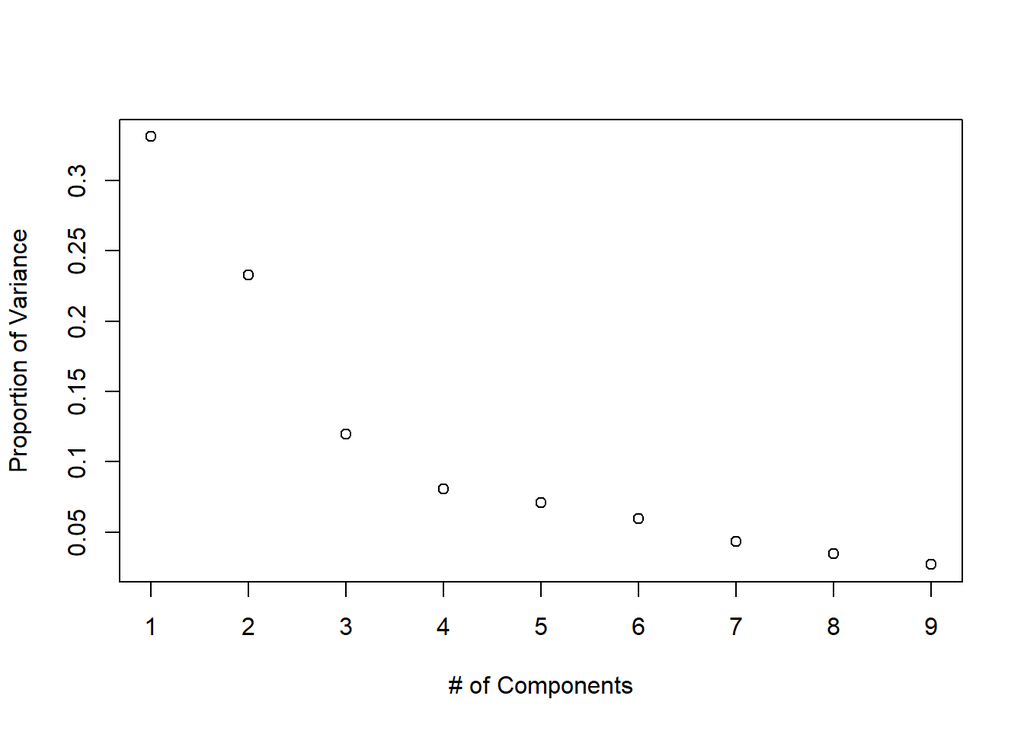

```r
plot(summary(pca_res)$importance[2,],
    xaxt = 'n',
    yaxt = 'n',
    ylab = 'Proportion of Variance',
    xlab = '# of Components')
axis(1, at = 1:9, labels = 1:9)
axis(2, at = seq(0, 0.35, 0.05), labels = seq(0, 0.35, 0.05))
```

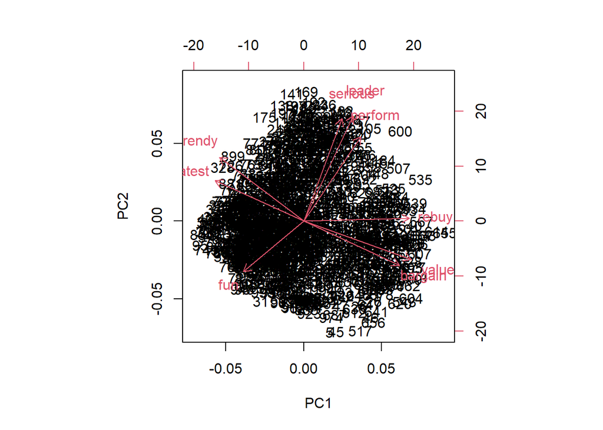

```r
#Preceptual Map for products (show data in PC1-PC2 space)
 # bottom-horizontal-axis: PC1
 # top-horizontal-axis: weight of PC1 in main variables
 # right-vertical-axis: weight of PC2 in main variables
 # left-vertical-axis: PC2
biplot(pca_res)
```

> According to the bi-plot, the space has been divided to 4 regions (same red-vectors (having same weight in of PC1 and PC2) make a region)
- four regions (cluster variables based-on their weight in PC1 and PC2):
  1. leadership cluster (serious, leader, perform) -> market leadership
  2. value cluster (rebuy, value, bargain) -> benefit/cost ratio
  3. trendiness cluster (trendy, latest)
  4. fun cluster (fun)

Actually, customers are measure different brands in 4 index

### 6.1.2 Run 2

Simplify the problem by running PCA on ‘brand_mean’ (10 row) instead of whole dataset (1000 row)

This helps us to have coordination of brands on bi-plot

```r
brand_mean_pca <- prcomp(brand_mean, scale = T)
summary(brand_mean_pca)
```

```
## Importance of components:
##                           PC1    PC2    PC3     PC4     PC5     PC6     PC7
## Standard deviation     2.1345 1.7349 0.7690 0.61498 0.50983 0.36662 0.21506
## Proportion of Variance 0.5062 0.3345 0.0657 0.04202 0.02888 0.01493 0.00514
## Cumulative Proportion  0.5062 0.8407 0.9064 0.94842 0.97730 0.99223 0.99737
##                            PC8     PC9
## Standard deviation     0.14588 0.04867
## Proportion of Variance 0.00236 0.00026
## Cumulative Proportion  0.99974 1.00000
```

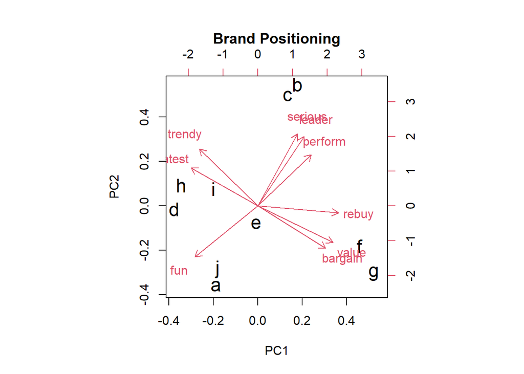

```r
biplot(brand_mean_pca, main = 'Brand Positioning', cex = c(1.5, 1))  # Perceptual Map for brands
```

Now, we can see that the different brands in PC1-PC2 space, are positioned where (near which feature-clusters)?

Some Questions for analysis results:

- What does the map tell us?
  - brand f and g are valueable brands in customer mindset (are near to value cluster and have good benefit/cost ratio)
  - brand c and b are leader of market (forerunner) brands in customer mindset
  - brand a and j are fun brands
  - brand d and h and i are innovative brands
- Suppose that you are the brand manager for brand e
  - your brand is famous as nothing!
  - from marketing aspect, your brand is known as nothing between customers and this is so bad in marketing; because the customers don’t know why should choose brand e (for what reason)?
  - customer who looks for leadership brand and performance, chooses c or b brands.
  - customer who looks for low-cost and good-benefit, chooses f or g brands.
  - customer who looks for latest products, chooses d or h or i brands.
- What should you do about the position of your brand e?
  - two possible solutions:
    - follow other brands (where is other brands position in this industry? choose a position and close yourself to there)
    - fill a gap (position yourself in a gap): value-leadership

For more information check the [Github](https://github.com/mamomen1996/R_CS_10) repository.